# Dominik Sawicki 145402, Sebastian Szczepaniak 145280

# Zadanie 1 - aktywnosc slonca

Plik spots.txt zawiera wartości aktywności Słońca w kolejnych miesiącach. Wykreśl ten sygnał oraz jego spektrum. Za pomocą FFT, oblicz częstotliwość cyklu aktywności słonecznej. Przydatne mogą być następujące konstrukcje:

array = genfromtxt(‘spots.txt’) (lub array=[float(x) for x in open('spots.txt').read().split()])

x = max(array)

```python
# importing libraries
import numpy as np
import matplotlib.pyplot as plt
```

```python
# loading the data
data = np.genfromtxt('data/spots.txt')
data
```

```
array([24.1, 25.1, 26.6, ..., 76.3, 36.4, 31.4])
```

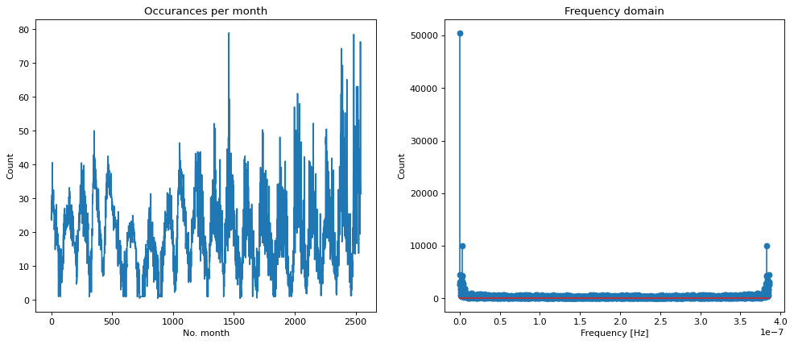

```python
data_f = np.abs(np.fft.fft(data))  # applying discrete fourier transform
w = 1/(24*3600*30)  # 1/month_in_seconds, the sampling frequency
n = len(data)

freqs = np.linspace(0, w, n)


plt.figure(figsize=(15, 6), dpi=80)
plt.subplot(1, 2, 1)
plt.title('Occurances per month')
plt.ylabel('Count')
plt.xlabel('No. month')
plt.plot(data)

plt.subplot(1, 2, 2)
plt.title('Frequency domain')
plt.stem(freqs, data_f, '-*', use_line_collection=True)
plt.xlabel('Frequency [Hz]')
plt.ylabel('Count')

plt.show()
```

##### W celu wyznaczenia częstotliwości cyklu należy wybrać częstotliwość najwyższego prążka (poza zerowym).

```python
occ_freq, _ = freqs[1:][data_f[1:] > 5000]
period_in_years = (1/(occ_freq))/(3600*24*30*12)

print(f'Occurance frequency [in Hz]: {occ_freq:.3e}')
print(f'The period [in years]: {period_in_years:.3f}')
```

```
Occurance frequency [in Hz]: 2.885e-09
The period [in years]: 11.145
```

##### Częstotliwość cyklu aktywności słonecznej jest równa około 2.8nHz, zatem cykl trwa około 11lat.

# Zadanie 2 - proste filtrowanie

Wykreśl sygnał $sin(2*pi*t) + sin(4*pi*t)$, T=1s, w=20Hz. Za pomocą FFT, przekształć sygnał do dziedziny częstotliwości. Następnie usuń składowe o częstotliwości 2Hz. Tak zmodyfikowany sygnał przekształć do dziedziny czasu i wykreśl go.

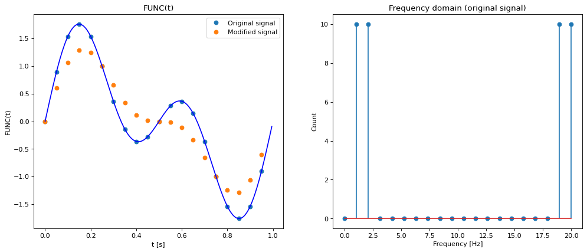

```python
T = 1
w = 20
TW = 1/w
t = np.arange(0, T, TW)
n = len(t)

FUNC = lambda t: np.sin(2*np.pi*t) + np.sin(4*np.pi*t)
signal = FUNC(t)  # calculating the original signal

base_t = np.arange(0, T, 1/200)
base_signal = FUNC(base_t)  # creating a smoother original signal

signal_f = np.fft.fft(signal)  # applying discrete fourier transform
freqs = np.linspace(0, w, n)
abs_signal_f = np.abs(signal_f)

to_filter = [2]  # creating an indices mask to filter the original signal
filtered_signal_f = np.copy(signal_f)
filtered_signal_f[to_filter] = 0  # removing the 2Hz frequency

filtered_signal = np.real(np.fft.ifft(filtered_signal_f))  # applying inverse dicrete fourier transform

# plotting
plt.figure(figsize=(15, 6), dpi=80)
plt.subplot(1, 2, 1)
plt.title('FUNC(t)')
plt.ylabel('FUNC(t)')
plt.xlabel('t [s]')
plt.plot(t, signal, 'o')
plt.plot(t, filtered_signal, 'o')
plt.plot(base_t, base_signal, color='blue')
plt.legend(['Original signal', 'Modified signal'])

plt.subplot(1, 2, 2)
plt.title('Frequency domain (original signal)')
plt.stem(freqs, abs_signal_f, '-*', use_line_collection=True)
plt.xlabel('Frequency [Hz]')
plt.ylabel('Count')

plt.show()
```

##### Prążkiem odpowiedzialnym za częstotliwość 2Hz jest prążek nr. 3 (prążek o indeksie 2 w tablicy)

# Zadanie 3 - Informacja o fazie

Wykreśl sygnał $sin(2*pi*t) + sin(4*pi*t)$, T=1s, w=20Hz. Tym razem oprócz spektrum, wykreśl wykres z informacją o fazie poszczególnych częstotliwości (faza = arg(z)), gdzie z=a+bi. To samo wykonaj dla sin(2*pi*t) + cos(4*pi*t). Porównaj otrzymane wykresy. Przydatna może być funkcja angle (z parametrem deg=True)

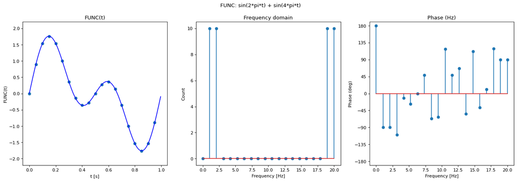

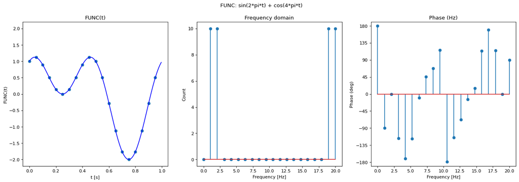

```python
def func_1(t):
    """sin(2*pi*t) + sin(4*pi*t)"""
    return np.sin(2*np.pi*t) + np.sin(4*np.pi*t)


def func_2(t):
    """sin(2*pi*t) + cos(4*pi*t)"""
    return np.sin(2*np.pi*t) + np.cos(4*np.pi*t)


T = 1
w = 20
TW = 1/w
t = np.arange(0, T, TW)
n = len(t)

funcs = [func_1, func_2]
for func in funcs:
    signal = func(t)

    base_t = np.arange(0, T, 1/200)
    base_signal = func(base_t)  # creating a smoother original signal

    freqs = np.linspace(0, w, n)
    signal_f = np.fft.fft(signal)
    abs_signal_f = np.abs(signal_f)

    phase = np.angle(signal_f, deg=True)

    plt.figure(figsize=(20, 6), dpi=80)
    plt.suptitle(f'FUNC: {func.__doc__}')
    plt.subplot(1, 3, 1)
    plt.title('FUNC(t)')
    plt.ylabel('FUNC(t)')
    plt.xlabel('t [s]')
    plt.ylim(-2.2, 2.2)
    plt.plot(t, signal, 'o')
    plt.plot(base_t, base_signal, color='blue')

    plt.subplot(1, 3, 2)
    plt.title('Frequency domain')
    plt.stem(freqs, abs_signal_f, '-*', use_line_collection=True)
    plt.xlabel('Frequency [Hz]')
    plt.ylabel('Count')

    plt.subplot(1, 3, 3)
    plt.title('Phase (Hz)')
    plt.stem(freqs, phase, '-*', use_line_collection=True)
    plt.ylim((-190, 190))
    plt.yticks(range(-180, 181, 45))
    plt.xlabel('Frequency [Hz]')
    plt.ylabel('Phase (deg)')

    plt.show()
```

##### Wykresy spektrum dla tych dwóch funkcji są identyczne, natomiast wykresy faz dla każdej częstotliwości znacząco różnią się od siebie.

# Zadanie 4 - plik wejsciowy audio

Wczytaj plik err.wav. Wykreśl jego spektrum. Spróbuj także skali logarytmicznej. Określ dominujące w sygnale częstotliwości. Przydatne:

import scipy.io.wavfile

w, signal = scipy.io.wavfile.read('err.wav')

signal = [s[0] for s in signal] #Tylko pierwszy kanał

yscale(‘log’)

spectrum[::10] # co 10-ty element

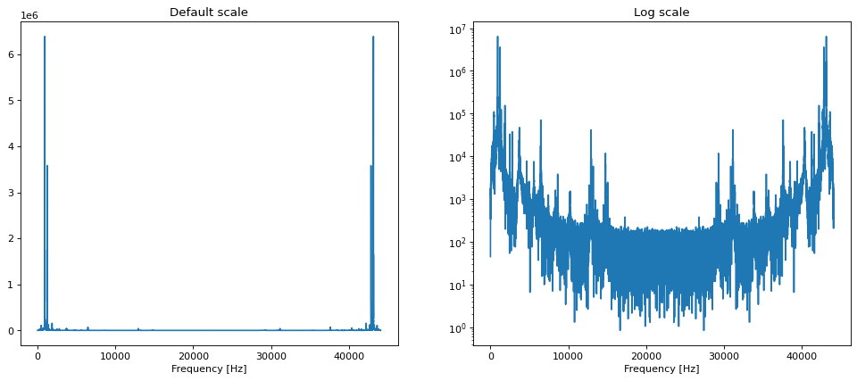

```
[  929.74183167   930.77030714   931.79878262   932.8272581
  1242.39837683  1243.42685231 42857.60162317 42858.63009865
 43168.20121738 43169.22969286 43170.25816833 43171.28664381]
```

```python
import scipy.io.wavfile

w, signal = scipy.io.wavfile.read('data/err.wav')
signal = signal[:, 0]  # only the first channel
signal_fft = np.fft.fft(signal)
abs_signal_fft = np.abs(signal_fft)
freqs = np.linspace(0, w, len(signal))

plt.figure(figsize=(15, 6), dpi=80)
plt.subplot(1, 2, 1)
plt.title('Default scale')
plt.xlabel('Frequency [Hz]')
plt.plot(freqs, abs_signal_fft)

plt.subplot(1, 2, 2)
plt.title('Log scale')
plt.xlabel('Frequency [Hz]')
plt.plot(freqs, abs_signal_fft)
plt.yscale('log')

plt.show()

dominant_freqs = freqs[abs_signal_fft > 3e6]
print(dominant_freqs)
```

##### Dominującymi częstotliwościami są częstotliwości 929-932Hz oraz 1242-1243Hz. Pozostałe częstotliwości w tablicy są ich lustrzanym odbiciem.